# Splicing report

How much intronic RNA is detected during *Dictyostelium discoideum* development, and what can it tell us about splicing? This report compares total single-cell RNA (snapTotal-seq), poly(A) single-cell RNA (10x), and rRNA-depleted bulk RNA from AX4.

At 0 h and 16 h, intronic evidence makes up **0.59%–1.33%** of assigned counts in the shared gene set. Detected introns are **1.08–1.17 times as long** as expression-matched undetected introns. The intronic fraction is higher at 16 h in all three methods, and the poly(A) increase survives the technical checks in section 5. None of these measurements is a direct splicing rate.

**Convention.** Unless stated otherwise, comparisons that include poly(A) use five poly(A) cell subsets matched to snapTotal's exon depth (section 2), reported as the median and range across subsets. Section 8 collects the key numbers.

## 1. Data and counting

All three methods were recounted from their alignments with one set of rules, on 7,785 nuclear, intron-bearing protein-coding genes with a single annotated transcript.

| Method | Cells or libraries at 0 h / 16 h | Time points |
| --- | --- | --- |
| Total scRNA ([snapTotal-seq](https://www.nature.com/articles/s41467-024-50291-3)) | 149 / 164 cells after QC, two plates per time point | 0, 16 h |
| Poly(A) scRNA (10x, AX4 atlas) | 6,626 / 11,827 atlas cells, three tagged replicate series | 0–20 h, every 4 h |
| Bulk total RNA ([Rosengarten et al.](https://academic.oup.com/g3journal/article/7/2/387/6027566), GSE90829) | 2 / 1 libraries | 0–24 h, every 2 h |

Choices that affect interpretation: counting is **unstranded** for all methods, because snapTotal does not keep strand; reads overlapping any other annotated gene are **ambiguous** and excluded; and a unit showing a splice through the same intron is **conflicting** and excluded. The **intronic fraction** is I / (I + E), where I counts units with any intronic base and E counts exon-only units. It is a fraction of observed evidence, not of transcripts retaining an intron.

**Counting and replicate details**

Only primary, uniquely mapped alignments are counted (NH = 1, MAPQ = 255). A counting unit is one cell–gene–UMI combination in single-cell data (snapTotal: valid 5-base UMIs from read 2; poly(A): Cell Ranger CB/UB tags) or one fragment in bulk data, with both mates assessed together. Each accepted unit is counted once. Exon coverage does not cancel intronic evidence in the same unit. The retained gene models are identical in the two single-cell references; the poly(A) reference also contains the act15GFP, mCerulean and mCherry reporters.

Poly(A) tags identify replicate series within each multiplexed library; that the same tag is the same series across time rests on the experimenter's records. Replicate analyses use the published tag assignments; untagged cells stay in pooled results only. Cells are not independent biological replicates. The bulk comparison at 0 and 16 h uses the retained libraries; the full bulk time course is in section 7.

## 2. Intronic abundance and gene detection

**Intronic evidence is at most 1.33% of counts in every method and is higher at 16 h in all three, yet it is spread across many genes:** 40%–97% of expressed genes have at least one intronic count.

**Depth matching.** Poly(A) has far more cells and counts than snapTotal, and deeper data detect more introns. Five random orders of poly(A) cells are therefore drawn at each time point, each stopping at snapTotal's exon-UMI total, and all counts and matching are recomputed on each subset. This matches exon depth, not capture chemistry. Bars use all cells; open circles show the five subsets.

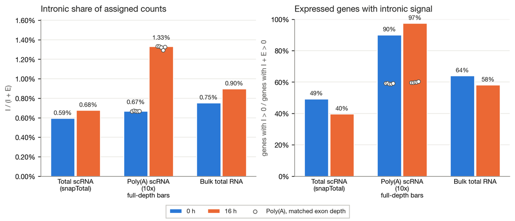

Left: intronic share I / (I + E). Right: share of expressed genes with at least one intronic count. Bars use all cells or libraries; open circles are the five depth-matched poly(A) subsets.

| Method | Intronic fraction, 0 h / 16 h | Genes with intronic signal, 0 h / 16 h |
| --- | --- | --- |
| Total scRNA (snapTotal) | 0.593% / 0.676% | 3,425/6,958 (49%) / 2,865/7,232 (40%) |
| Poly(A) scRNA, all cells | 0.668% / 1.330% | 6,969/7,741 (90%) / 7,576/7,778 (97%) |
| Bulk total RNA | 0.752% / 0.896% | 4,665/7,287 (64%) / 4,372/7,522 (58%) |

| Hour | Poly(A) subset cells | Poly(A) intronic fraction at matched depth | Poly(A) expressed genes with intronic signal at matched depth |
| --- | --- | --- | --- |
| 0 | 554–598 | 0.664%–0.671% | 58.7%–59.3% |
| 16 | 347–362 | 1.294%–1.333% | 59.6%–60.4% |

Depth barely changes the poly(A) intronic fraction, but it strongly changes gene detection. With all cells, poly(A) finds intronic signal in 90% and 97% of expressed genes. At snapTotal's exon depth this falls to 58.7%–59.3% and 59.6%–60.4%, compared with snapTotal's 49.2% and 39.6%.

Despite being designed to capture non-polyadenylated RNA, snapTotal does not show a higher intronic fraction than poly(A).

**Full-depth assigned and excluded counts**

All cells or libraries, full-depth poly(A). Exclusions are gene–unit assignments, so one ambiguous unit can appear at several genes; a unit both ambiguous and conflicting is listed as ambiguous.

| Method | Hour | Exon-only units (E) | Intronic units (I) | Ambiguous gene | Splice conflict |
| --- | --- | --- | --- | --- | --- |
| Total scRNA | 0 | 11,790,377 | 70,339 | 8,660 | 23,631 |
| Total scRNA | 16 | 3,340,238 | 22,739 | 1,724 | 4,215 |
| Poly(A) scRNA | 0 | 133,220,554 | 895,523 | 212,542 | 136,672 |
| Poly(A) scRNA | 16 | 111,875,547 | 1,508,195 | 314,146 | 292,193 |
| Bulk total RNA | 0 | 6,533,758 | 49,490 | 9,150 | 15,654 |
| Bulk total RNA | 16 | 3,178,575 | 28,747 | 5,087 | 8,438 |

## 3. Intron length

**Detected introns are consistently longer than expression-matched controls, but only modestly: 1.08–1.17× in every method and hour.**

Are introns with detectable unspliced evidence longer than expression-matched introns without it? Because a longer intron is also a bigger target for stray reads, an intron counts as detected only from reads crossing an annotated exon–intron boundary with 10 bases on each side (the **anchors**). Each detected intron (**case**, ≥2 supporting units, in ≥2 cells for single-cell data) is paired with an intron with no intronic reads (**control**) from a gene of similar expression. The paired ratio is 2^median log2(case length / control length), so 1.10 means about 10% longer.

**Matching details**

Boundary support requires one uninterrupted aligned block (no indels) with ≥10 exon and ≥10 intron bases. Targets need ≥20 intron bases and ≥10 bases in each adjacent exon. Introns with some evidence but too little to be cases are dropped from both groups. Parent genes need ≥20 exon counts and, for single-cell data, exon detection in ≥5 cells.

Matching uses log2(exon counts + 1) and, for single-cell data, log2(exon-detected cells + 1), caliper 0.25 on each, one control per case, without replacement; length is not used. A ratio is reported only with ≥20 pairs and absolute standardized mean difference < 0.1 on each variable. Brackets are the 2.5–97.5% range over 500 resamples of parent genes with matching repeated; they reflect gene sampling, not biological replicates.

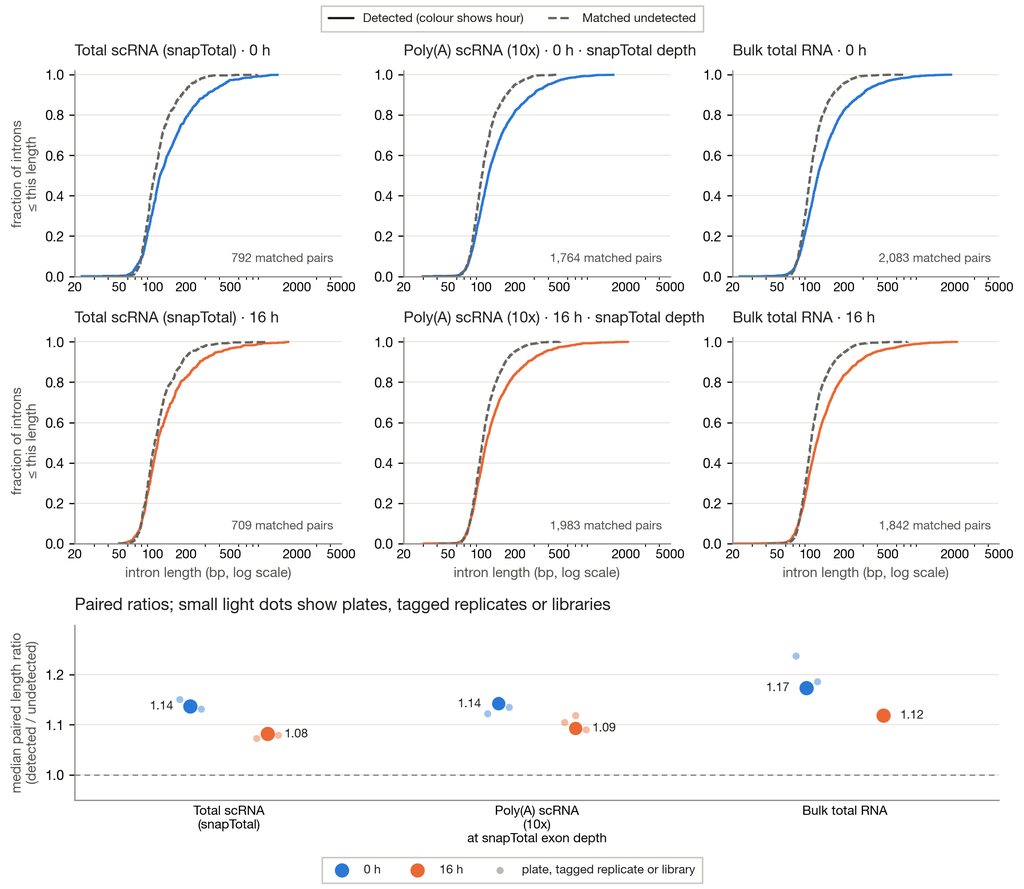

Upper panels: cumulative length distributions of detected introns (solid) and matched controls (dashed); log length axis. Bottom: paired ratio per method and hour; light dots are individual plates, tagged replicates or libraries.

In every panel the solid curve sits slightly right of the dashed one, mainly above about 100 bp: the difference is in the upper part of the length distribution, not a wholesale shift.

| Method | Hour | Detected cases | Matched pairs | Cases matched | 10-bp ratio | 5-bp ratio | Relaxed-control ratio (pairs) |
| --- | --- | --- | --- | --- | --- | --- | --- |
| Total scRNA | 0 | 819 | 792 | 97% | 1.137 [1.08–1.18] | 1.129 [1.07–1.16] | 1.109 [1.05–1.15] (817) |
| Total scRNA | 16 | 714 | 709 | 99% | 1.082 [1.02–1.11] | 1.077 [1.03–1.11] | 1.047 [1.01–1.08] (712) |
| Poly(A) scRNA, snapTotal depth | 0 | 2,018–2,159 | 1,713–1,801 | 83%–85% | 1.142 (1.12–1.15) | 1.125 (1.11–1.15) | 1.104 (1.09–1.12) (1,856–1,988) |
| Poly(A) scRNA, snapTotal depth | 16 | 2,406–2,461 | 1,981–2,026 | 81%–82% | 1.093 (1.09–1.12) | 1.102 (1.09–1.11) | 1.067 (1.06–1.09) (2,185–2,240) |
| Bulk total RNA | 0 | 2,343 | 2,083 | 89% | 1.173 [1.14–1.20] | 1.165 [1.14–1.19] | 1.154 [1.11–1.17] (2,288) |
| Bulk total RNA | 16 | 2,032 | 1,842 | 91% | 1.119 [1.09–1.15] | 1.116 [1.09–1.15] | 1.093 [1.06–1.12] (1,955) |

5-bp: same comparison with 5-bp anchors. Brackets: 95% gene-resampling interval.

**Control definition.** Requiring controls to have no intronic reads at all can favour short controls. Relaxing it to "no boundary units with ≥5-bp anchors" (last column) lowers the ratios to 1.05–1.15 in snapTotal and bulk, all intervals above 1, and to 1.06–1.12 in poly(A).

At full poly(A) depth only 13% and 2% of poly(A) cases find a control (1,059 and 241 pairs), with ratios of 1.12 and 1.17; the 16 h value rests on few pairs.

**Why boundary-only.** In snapTotal, counting only reads fully inside introns gave length ratios of 1.89 (0 h) and 2.35 (16 h); adding boundary reads gave 1.25 and 1.18; the boundary-only analysis above gives 1.14 and 1.08. A read can lie fully inside an intron only if the intron is longer than the read, so body reads preferentially find long introns. Most of the apparent twofold effect is this detection bias; a modest effect remains in all six comparisons. (The earlier pipeline also differed in other rules, so the steps are not a clean decomposition.)

## 4. Gene span

Using the same matching at gene level (cases: ≥2 intronic units of any kind, including reads inside introns; controls: none), genes with intronic evidence are consistently **shorter** than matched controls in genomic span (start to end, including introns). A ratio of 0.80 means 20% shorter. Intron length and gene span use different cases, so their directions need not agree.

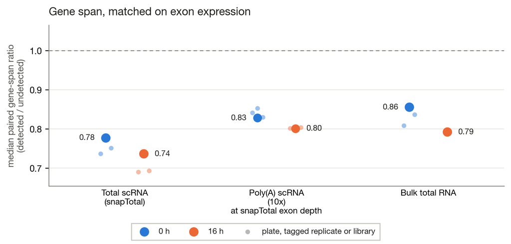

Median paired gene-span ratio (detected / undetected); light dots are plates, tagged replicates or libraries. Dashed line: no difference.

At full poly(A) depth nearly every expressed gene has intronic signal, so only 4% and 1% of cases find a control (270 and 46 pairs), and the ratios (0.79 and 0.55) describe only a small matched minority.

| Method | Hour | Detected cases | Matched pairs | Cases matched | Gene-span ratio |
| --- | --- | --- | --- | --- | --- |
| Total scRNA | 0 | 2,143 | 1,570 | 73% | 0.778 [0.73–0.82] |
| Total scRNA | 16 | 1,480 | 1,242 | 84% | 0.737 [0.69–0.78] |
| Poly(A) scRNA, snapTotal depth | 0 | 2,790–2,892 | 1,612–1,651 | 56%–59% | 0.828 (0.81–0.87) |
| Poly(A) scRNA, snapTotal depth | 16 | 2,886–2,974 | 1,533–1,570 | 52%–54% | 0.801 (0.78–0.82) |
| Bulk total RNA | 0 | 3,267 | 1,421 | 43% | 0.856 [0.79–0.89] |
| Bulk total RNA | 16 | 2,718 | 1,442 | 53% | 0.793 [0.75–0.85] |

Brackets: 95% gene-resampling interval.

## 5. Checks on the poly(A) 16 h increase

The full-depth poly(A) intronic fraction rises from 0.67% at 0 h to 1.33% at 16 h (all cells). Checks for technical and compositional explanations:

[output not shown]

The increase persists under every check. Antisense evidence and unannotated transcripts could still contribute; adjusted values here are sensitivity checks, and sections 2 and 8 keep the original counts.

**Detailed checks: cells, genes, priming, alignment and read coverage**

**Cells.** The whole 16 h poly(A) distribution shifts towards higher intronic fractions; the increase is not confined to a few extreme cells. The median per-cell fraction rises from 0.67% to 1.32%, and removing the 5% of cells with the highest fractions leaves 0.66% and 1.30%. Per-cell fraction is only weakly related to exonic depth (Spearman ρ = -0.25 at 0 h, 0.06 at 16 h).

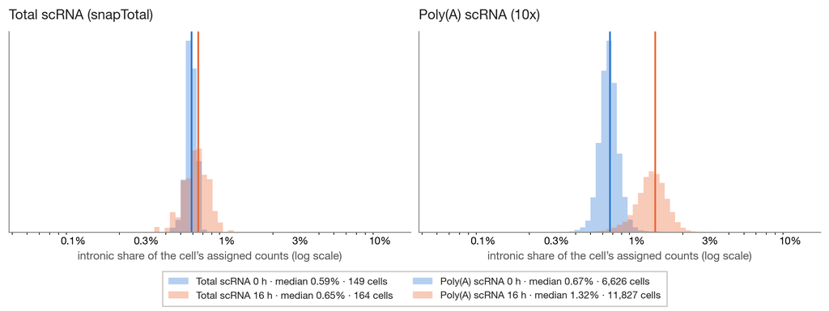

Per-cell intronic fraction, normalized density within each time point (log axis); vertical lines mark medians.

**Tagged replicates.** Each tagged series was subsampled five times to snapTotal's exon depth (values are medians across subsets). All three reproduce the increase in intronic fraction, from 0.66%–0.67% to 1.33%–1.35%, and the longer detected introns and shorter gene spans of sections 3–4.

| Tag | Hour | Intronic fraction | Intron-length ratio | Gene-span ratio |
| --- | --- | --- | --- | --- |
| act15GFP | 0 | 0.664% | 1.12 | 0.84 |
| act15GFP | 16 | 1.348% | 1.11 | 0.80 |
| mCerulean | 0 | 0.674% | 1.15 | 0.85 |
| mCerulean | 16 | 1.327% | 1.12 | 0.80 |
| mCherry | 0 | 0.664% | 1.13 | 0.83 |
| mCherry | 16 | 1.342% | 1.09 | 0.80 |

**Genes.** The increase is not driven by a few highly expressed genes. Half of the intronic counts come from 29 genes at 0 h but 165 at 16 h, so the signal is broader at 16 h. Removing the largest contributors at either time (the same genes at both) still leaves a 2.3–2.8× increase:

| Top N removed | Genes removed | 0 h | 16 h | 16 h ÷ 0 h |
| --- | --- | --- | --- | --- |
| 10 | 18 | 0.46% | 1.09% | 2.38 |
| 25 | 42 | 0.39% | 1.03% | 2.65 |
| 50 | 89 | 0.35% | 0.96% | 2.75 |
| 100 | 171 | 0.33% | 0.87% | 2.68 |
| 200 | 323 | 0.31% | 0.79% | 2.56 |
| 500 | 768 | 0.28% | 0.64% | 2.30 |

Gene by gene, the median within-gene rise in poly(A) is 1.65–1.76× across minimum exon-count thresholds of 100–1,000, with 76%–81% of genes rising; snapTotal rises by a similar factor.

**Internal priming.** Oligo(dT) priming inside introns would place intronic UMI ends just upstream of A-rich sequence. Sense intronic ends were compared with random positions in the same introns, for two A-richness definitions and three distances. **There is a priming signature at both times, but it is not consistently stronger at 16 h:** the observed-minus-random excess is 6–29 percentage points at 0 h and 6–22 at 16 h, larger at 16 h in 4 of 6 settings.

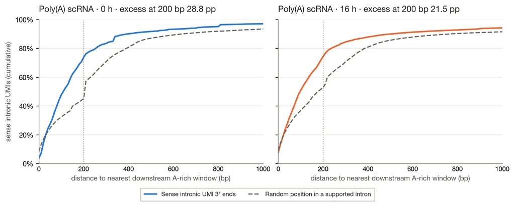

Cumulative distance from sense intronic UMI 3′ ends (solid) and random intronic positions (dashed) to the nearest downstream A-rich window (≥9 A in 10 bp); dotted line at 200 bp.

As a deliberately conservative correction, antisense intronic units (which rise from 7% to 19%) were dropped and the largest excess was subtracted as if it were primed molecules. The fraction still rises from 0.44% to 0.85%.

**Alignment.** Misalignment of spliced reads into introns is rare: in reads simulated from 420 real introns, 0.14% of spliced reads were called intronic (1.7% with 1% sequencing errors), and none had 10-bp boundary support. **Rebuilding the counts from progressively cleaner reads keeps the increase at every tier**, and requiring 10-bp boundary support strengthens it.

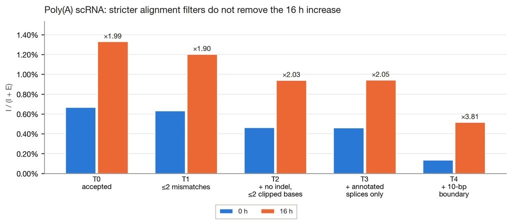

Poly(A) intronic fraction at 0 h and 16 h under cumulative alignment filters T0–T4 (see table).

| Tier | Cumulative requirement | Fraction, 0 h | Fraction, 16 h | 16 h ÷ 0 h |
| --- | --- | --- | --- | --- |
| T0 | accepted by the shared counting | 0.668% | 1.330% | 1.99 |
| T1 | at most 2 mismatches | 0.632% | 1.204% | 1.90 |
| T2 | + no indel, at most 2 soft-clipped bases | 0.464% | 0.940% | 2.03 |
| T3 | + every splice annotated, overhangs ≥10 bp | 0.460% | 0.943% | 2.05 |
| T4 | + intronic units need a 10-bp boundary | 0.135% | 0.516% | 3.81 |

**Reads per UMI.** 16 h has more reads per exon-only UMI (1.91 vs 1.64), which could make intronic parts of molecules easier to catch. But the increase holds among single-read UMIs (0.68% to 1.38%), and reweighting 16 h to the 0 h read-support distribution gives 1.34%. Near-duplicate intronic UMIs (one base apart, same cell and gene) are rare (0.1% and 0.4%).

**Read-coverage examples.** Two well-covered genes with rising intronic fractions: DDB_G0272190 shows intronic coverage across the gene; DDB_G0291255 shows soft-clipped reads piling up near one exon, possibly an unannotated transcript start. In multi-intron genes the first intron's share of intronic assignments rises from 19% to 27%.

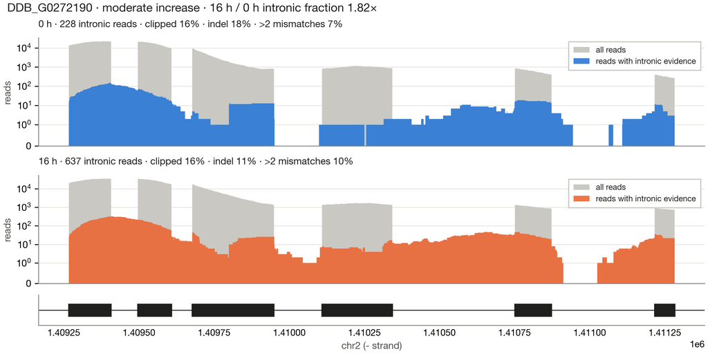

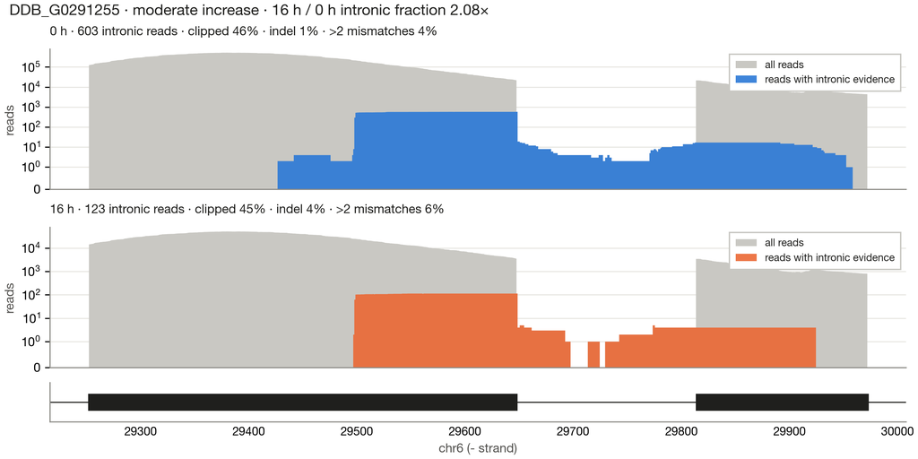

## 6. Splicing time, intron position and RNA velocity

At each eligible intron (section 3 rules), a second pass counts **unspliced (U)** units, which cross an exon–intron boundary with 10-bp anchors, and **spliced (S)** units, which splice exactly across the annotated intron. **U/S rises from 0 h to 16 h in all three methods, and across development in bulk:** measured every 2 h, bulk U/S is lowest at 0 h (1.70%), lies between 2.6% and 4.2% from 2 to 22 h, climbing after 8 h, and is highest at 24 h (5.18%). Poly(A) U/S uses all cells, not the depth-matched subsets.

**How long introns persist.** At steady state, U/S ≈ intron persistence time ÷ mRNA lifetime. With a 2 h mRNA half-life, this gives about **1–9 minutes** in the total-RNA methods (snapTotal at 0 and 16 h, bulk at all time points), and 0.3–43 minutes across all methods and the published 0.9–9.6 h half-life range. These numbers come from the model's assumptions (steady state, equal capture of U and S, unmeasured lifetimes); they are not a measured splicing time.

**Model and counting details**

Per-molecule logic: if introns last 1 minute and spliced mRNA about 100 minutes, we expect about 1 unspliced copy per 100 spliced. So persistence ≈ U/S × mean spliced-mRNA lifetime (half-life / ln 2). An unspliced molecule has two boundaries where U can be counted and a spliced one only one junction, so the range includes the result halved (factor 0.5–1). Half-lives are from [Shapiro et al. 1988](https://pubmed.ncbi.nlm.nih.gov/2898728/) (selected mRNAs in amoebae), not our cells at 0 and 16 h. Developing cells need not be at steady state, and poly(A) capture can under-sample unspliced RNA. U requires no splice skip overlapping the intron; S requires no intronic aligned bases at that intron; conflicting units are excluded intron by intron, and one unit can count at several introns. The pass reproduces the section 2 counts exactly at 0 h and 16 h. Counts are pooled across cells.

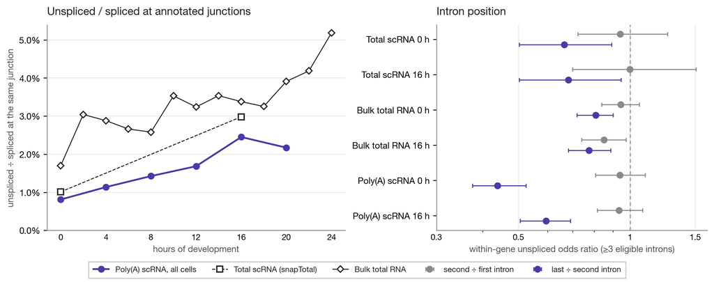

Left: unspliced ÷ spliced units at the same annotated junctions (poly(A) every 4 h, bulk every 2 h, snapTotal at 0 and 16 h). Right: within-gene odds ratios by intron position with 95% gene-resampling intervals; dashed line: no difference.

| Method | Hour | U | S | U/S | Scenario minutes (2 h half-life) | Scenario minutes (0.9–9.6 h half-lives) |
| --- | --- | --- | --- | --- | --- | --- |
| Total scRNA | 0 | 10,910 | 1,079,004 | 1.01% | 0.9–1.8 | 0.4–8 |
| Total scRNA | 16 | 7,436 | 249,541 | 2.98% | 2.6–5.2 | 1.2–25 |
| Poly(A) scRNA | 0 | 219,395 | 27,082,177 | 0.81% | 0.7–1.4 | 0.3–7 |
| Poly(A) scRNA | 4 | 190,273 | 16,754,167 | 1.14% | 1.0–2.0 | 0.4–9 |
| Poly(A) scRNA | 8 | 319,435 | 22,414,699 | 1.43% | 1.2–2.5 | 0.6–12 |
| Poly(A) scRNA | 12 | 265,656 | 15,778,149 | 1.68% | 1.5–2.9 | 0.7–14 |
| Poly(A) scRNA | 16 | 712,839 | 29,091,896 | 2.45% | 2.1–4.2 | 1.0–20 |
| Poly(A) scRNA | 20 | 361,237 | 16,636,281 | 2.17% | 1.9–3.8 | 0.8–18 |
| Bulk total RNA | 0 | 16,624 | 978,748 | 1.70% | 1.5–2.9 | 0.7–14 |
| Bulk total RNA | 2 | 22,341 | 734,446 | 3.04% | 2.6–5.3 | 1.2–25 |
| Bulk total RNA | 4 | 17,655 | 612,780 | 2.88% | 2.5–5.0 | 1.1–24 |
| Bulk total RNA | 6 | 20,766 | 780,621 | 2.66% | 2.3–4.6 | 1.0–22 |
| Bulk total RNA | 8 | 19,159 | 742,724 | 2.58% | 2.2–4.5 | 1.0–21 |
| Bulk total RNA | 10 | 24,215 | 685,695 | 3.53% | 3.1–6.1 | 1.4–29 |
| Bulk total RNA | 12 | 13,217 | 408,075 | 3.24% | 2.8–5.6 | 1.3–27 |
| Bulk total RNA | 14 | 21,391 | 604,946 | 3.54% | 3.1–6.1 | 1.4–29 |
| Bulk total RNA | 16 | 14,517 | 429,635 | 3.38% | 2.9–5.8 | 1.3–28 |
| Bulk total RNA | 18 | 33,432 | 1,027,979 | 3.25% | 2.8–5.6 | 1.3–27 |
| Bulk total RNA | 20 | 31,313 | 800,798 | 3.91% | 3.4–6.8 | 1.5–32 |
| Bulk total RNA | 22 | 18,561 | 443,568 | 4.18% | 3.6–7.2 | 1.6–35 |
| Bulk total RNA | 24 | 35,812 | 691,020 | 5.18% | 4.5–9.0 | 2.0–43 |

**Intron position.** In genes with ≥3 eligible introns, comparing U/S between introns (length-adjusted odds ratio; below 1 means lower U/S at the later intron):

- second vs first: 0.85–1.00, no consistent difference (only the bulk 16 h interval excludes 1);
- last vs second: 0.66–0.81 in snapTotal and bulk, and 0.44–0.59 in poly(A).

Terminal introns have lower U/S. This does not identify the mechanism (splicing, 3′-end processing or detection).

**Intron-position method**

Each compared intron needs ≥20 U + S units. Differences in log((U + 0.5)/(S + 0.5)) are regressed on log2 length ratios; the exponentiated intercept is the reported ratio. Each gene contributes one intron pair per contrast; intervals are 2.5–97.5% over 1,000 resamples of genes (shown in the figure). First, second and last refer to eligible introns after filtering.

**RNA velocity.** Do velocity transitions (scVelo, stochastic model; exon-only units as spliced, intronic units as unspliced) point towards later-collected cells? Across 4–16 h, **36.4%** of cells point later, against 31.6%–34.7% when unspliced counts are shuffled within each tagged replicate (central 95% of 100 shuffles; one-sided p = 0.010). 56.2% of these cells show no direction. Velocity therefore carries only a small amount of developmental information in these data.

**Velocity details**

666 atlas cells per tag at each of six time points (11,988 cells; smallest group 1,135); 475 velocity genes. A cell's collection-hour shift is the transition-weighted mean difference between its collection time and that of its predicted next states; mean shift +0.04 h against -0.10 to -0.06 h in shuffles. The 0 h and 20 h endpoints are excluded because they can only point one way. The per-tag rows come from one joint fit, not three independent models.

| Tagged replicate | Cells pointing later (4–16 h) | Within-replicate null, central 95% | Mean hour shift |
| --- | --- | --- | --- |
| act15GFP | 39.3% | 34.0%–37.6% | -0.02 h |
| mCerulean | 36.0% | 30.5%–33.8% | +0.08 h |
| mCherry | 33.9% | 30.3%–33.4% | +0.07 h |

All three tags exceed their shuffled range; act15GFP nevertheless has a negative mean shift.

## 7. Developmental time courses

Both series are counted with the section 1 rules at every time point: poly(A) every 4 h, subsampled to one fixed exon depth (snapTotal's 16 h total), and bulk every 2 h from all 23 libraries.

**Intronic fraction rises through development in poly(A), less clearly in bulk.** Poly(A) goes from 0.66% at 0 h to about 1.0% at 8–12 h, peaks at 1.34% at 16 h and is 1.15% at 20 h. Bulk is lowest at 0 h (0.75%), between 0.80% and 0.99% from 2 to 22 h without a steady trend, and highest at 24 h (1.16%).

**Detected introns are modestly longer than controls at every time point**: 1.08–1.11× in poly(A) from 4 h onwards (1.22× at 0 h) and 1.11–1.17× in bulk, without a clear monotonic pattern.

**Genes with intronic evidence are shorter than matched controls at every time point**, with descriptive ratios of 0.80–0.86× in poly(A) and 0.69–0.86× in bulk. In both series the ratio is highest at 0 h (0.86 and 0.86) and lower later in development. These associations do not establish a causal effect of gene length on splicing.

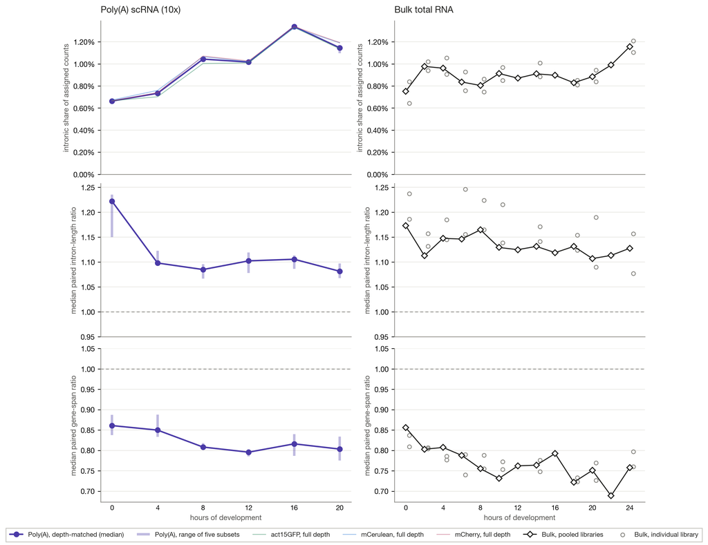

Top: intronic share I / (I + E). Middle: boundary-only paired intron-length ratio (section 3). Bottom: paired gene-span ratio (section 4); bulk matches only 36%–57% of cases. Dashed lines: no difference. Left: poly(A) depth-matched median with the range of five subsets; thin lines are the tagged replicates at full depth. Right: bulk, pooled libraries per time point, with individual libraries as open circles.

Between-library variation in bulk is comparable to the changes over time: libraries from the same time point differ by up to 0.20 percentage points in intronic fraction, 0.10 in intron-length ratio and 0.05 in gene-span ratio.

**Time-course details and bulk libraries**

Poly(A) subsets hold 157–443 cells (across all five draws per hour). At 16 h the target equals section 2's, so values agree with section 2 up to random draws; at 0 h the depth is lower than in section 3 (which matched snapTotal's larger 0 h total), and the length ratio is higher at this depth (1.22 vs 1.14). Replicate 2 at 12, 16 and 22 h was excluded in the original bulk publication, so those time points have one library; the others have two. The earlier bulk time course used a separate counting pipeline and is superseded.

| Hour | Library | Intronic fraction | Intron-length ratio | Gene-span ratio |
| --- | --- | --- | --- | --- |
| 0 | SRR5099643 | 0.642% | 1.24 | 0.81 |
| 0 | SRR5099656 | 0.838% | 1.19 | 0.84 |
| 2 | SRR5099644 | 1.019% | 1.13 | 0.80 |
| 2 | SRR5099657 | 0.939% | 1.16 | 0.81 |
| 4 | SRR5099645 | 1.053% | 1.14 | 0.79 |
| 4 | SRR5099658 | 0.904% | 1.18 | 0.78 |
| 6 | SRR5099646 | 0.926% | 1.16 | 0.74 |
| 6 | SRR5099659 | 0.757% | 1.25 | 0.79 |
| 8 | SRR5099647 | 0.745% | 1.16 | 0.75 |
| 8 | SRR5099660 | 0.861% | 1.22 | 0.79 |
| 10 | SRR5099648 | 0.967% | 1.14 | 0.77 |
| 10 | SRR5099661 | 0.849% | 1.22 | 0.75 |
| 12 | SRR5099649 | 0.870% | 1.12 | 0.76 |
| 14 | SRR5099650 | 1.007% | 1.17 | 0.78 |
| 14 | SRR5099662 | 0.883% | 1.14 | 0.75 |
| 16 | SRR5099651 | 0.896% | 1.12 | 0.79 |
| 18 | SRR5099652 | 0.808% | 1.12 | 0.72 |
| 18 | SRR5099663 | 0.850% | 1.15 | 0.73 |
| 20 | SRR5099653 | 0.942% | 1.09 | 0.77 |
| 20 | SRR5099664 | 0.837% | 1.19 | 0.73 |
| 22 | SRR5099654 | 0.989% | 1.11 | 0.69 |
| 24 | SRR5099655 | 1.103% | 1.08 | 0.76 |
| 24 | SRR5099665 | 1.207% | 1.16 | 0.80 |

## 8. Key results at 0 h and 16 h

Poly(A): depth-matched median (range). Brackets: 95% gene-resampling interval.

| Measurement | Total scRNA (snapTotal) 0 h | Total scRNA (snapTotal) 16 h | Poly(A) scRNA, snapTotal depth 0 h | Poly(A) scRNA, snapTotal depth 16 h | Bulk total RNA 0 h | Bulk total RNA 16 h |
| --- | --- | --- | --- | --- | --- | --- |
| Intronic share of assigned counts | 0.593% | 0.676% | 0.667% (0.664%–0.671%) | 1.327% (1.294%–1.333%) | 0.752% | 0.896% |
| Expressed genes with intronic signal | 49.2% | 39.6% | 59.2% (58.7%–59.3%) | 59.9% (59.6%–60.4%) | 64.0% | 58.1% |
| Paired gene-span ratio | 0.78 [0.73–0.82] | 0.74 [0.69–0.78] | 0.83 (0.81–0.87) | 0.80 (0.78–0.82) | 0.86 [0.79–0.89] | 0.79 [0.75–0.85] |
| cases matched | 73% | 84% | 57% (56%–59%) | 53% (52%–54%) | 43% | 53% |
| Paired boundary-only intron-length ratio | 1.14 [1.08–1.18] | 1.08 [1.02–1.11] | 1.14 (1.12–1.15) | 1.09 (1.09–1.12) | 1.17 [1.14–1.20] | 1.12 [1.09–1.15] |
| cases matched | 97% | 99% | 84% (83%–85%) | 82% (81%–82%) | 89% | 91% |
| Unspliced ÷ spliced at the same junction | 1.01% | 2.98% | 0.81%† | 2.45%† | 1.70% | 3.38% |

† Poly(A) U/S uses all cells; the junction pass was not run on the depth-matched subsets.

Across three chemistries, intronic evidence is 0.6%–1.3% of counts. It rises from 0 h to 16 h, detected introns are modestly longer than matched controls, and genes with intronic evidence are shorter. The persistence-time estimates are model-based, not measured splicing speeds.